# Lecture Introduction to statistical and supervised learning

BERN02

Author

Ullrika Sahlin

# Literature

ISL: 1, 2.1, 2.2, 4.1

# Statistical learning

Term used by the ISL book authors

> Statistical learning refers to a vast set of tools for understanding data. These tools can be classified as supervised or unsupervised. Broadly speaking, supervised statistical learning involves building a statistical model for predicting, or estimating, an output based on one or more inputs.
- prediction or estimation
- statistical modelling
- machine learning
- parametric and non-parametric methods
- data analysis: analysis using computational methods of existing data from databases or from designed experiments

## Supervised learning - general form

Consider
$$y = f(x) + \varepsilon$$
$y$ is observed response from the response (or dependent) random variable $Y$

$x=(x_1,\ldots,x_p)$ is a vector of observations of $p$ different predictors (or independent variables) $X=(X_1,\ldots,X_p)$

$\varepsilon$ is a random error term where we usually assume that the expected value is zero and does not depend on the predictors, i.e. $E(\varepsilon) = 0$

$f$ is an unknown function representing the systematic information that $X$ provides about $Y$

Statistical learning consists of a set of approaches for estimating the function $f$ for the purpose of predictive or parametric inference.

## Predictive inference

The goal is to make predictions.

The *quantity of interest* is a prediction of $Y$, $\hat{Y}$, for the predictors $X$, the estimate of the function $f$ with the argument $X$ is $\hat{Y}$

$$\hat{Y} = \hat{f}(X)$$

Assume that the estimated function $\hat{f}$ and the predictors $X$ is fixed. Then the only source of variation comes from the random errors $\varepsilon$.

The variance of a prediction is

$$V(\hat{Y}) = E\left( (\hat{Y}-Y)^2 \right) = \underbrace{\left( \hat{f}(X)-f(X)\right)^2}_{Reducible\ error} + \underbrace{V(\varepsilon)}_{Irreducible\ error}$$

**NoteShow it!**

Prove the equality!

$$E\left( (Y-\hat{Y})^2 \right) = E\left( (f(X) + \varepsilon -\hat{f}(X))^2 \right) = \left( f(X)-\hat{f}(X)\right)^2 + V(\varepsilon)$$

Supervised learning offers techniques for estimating the function $f$ with the aim of minimising the reducible error.

## Parametric inference

The goal is to understand the association between $Y$ and $X_1,\ldots,X_p$, e.g.

- Which predictors have a strong association with $Y$?
- What relationship describes this association (increasing/decreasing, linear/nonlinear)?

In parametric inference, the *quantity of interest* can be a parameter within a function, or a function among a set of candidate functions.

**Note**

The ISL book uses:

**Prediction** - Statistical learning is applied to build a model for making predictions.

**Inference** - Statistical learning is applied to learn something about the world.

I use *predictive inference* vs *parametric inference* because inference is required for both goals.

According to the Cambridge dictionary, *inference* is a guess that you make or an opinion that you form based on the information that you have.

# General approach for supervised learning

## Notations

For a vector, I write $x_i = (x_{i1},\ldots,x_{ip})$

$x_i$ is an observation of $X$.

$X$ is usually treated as a fixed variable (the alternative would be to treat it as a random variable), or a random variable with negligible error.

$y_i|x_i$ is an observation of the random variable $Y|X$.

It is common to drop the conditioning notation (assuming it is understood by the reader), and write $Y$ instead of $Y|X$ and $y_i$ instead of $y_i|x_i$

## Objective

Find a function $\hat{f}$ such that $Y\approx \hat{f}(X)$ for any observation $(X,Y)$

## Residual Sum of Squares

The variance of predictions of observed data $(y_1,x_1),\ldots,(y_i,x_i)$, where $i=1,\ldots,n$ can be estimated from the *Residual Sum of Squares*

$$RSS = \sum_{i=1}^{n} \left(y_i-\hat{f}(x_i)\right)^2 = \sum_{i=1}^{n} e_i^2$$

**Note**

Note that the **RSS** must be divided by a suitable factor to become an estimate of the prediction variance. What is a suitable factor depends on the *degrees of freedom* associated with the algorithm used.

# Regression versus Classification

In general, variables are

- Quantitative (continuous, discrete)
- Categorical (qualitative)

Statistical learning about the unknown function $f$ is termed

- *regression*, when the response variable $Y$ is quantitative

and

- *classification*, when the response variable $Y$ is categorical

The design of algorithms for statistical learning and ways to measure performance differ between regression and classification models.

# Model accuracy for regression

For regression the quality of a fitted model can be measured by the variance of predictions.

Assuming equal variance for all predictions, this variance can be estimated by the Mean Squared Error (MSE)

$$MSE = \frac{1}{n} \sum_{i=1}^{n}\left( y_i-\hat{f}(x_i)\right)^2$$

This can be done based on the

- *training data*, i.e. the data that were used to estimate the function, or
- *test data*, i.e. a data set held out from the start and not used for the estimation.

In general, $MSE_{train} < MSE_{test}$

Therefore, using the $MSE_{test}$ will reduce the risk of being over-confident in the model’s performance or, if the $MSE$ is used for model selection, the risk of over fitting the model.

*Cross-validation* is a method for estimating the $MSE_{test}$ using the training data. We go through this in a later lecture.

## Predictive variance

The variance of the difference between the actual value $Y|x_0$ and the prediction at point $x_0$, i.e. the predictive (or prediction) error, is

$$V\left(\hat{f}(x_0)-Y|x_0\right):=E\left( (\hat{f}(x_0)-Y|x_0)^2\right) = \underbrace{V\left(\hat{f}(x_0)\right)}_A + \underbrace{\left( \hat{f}(x_0)-f(x_0) \right)^2 }_B+ \underbrace{V(\varepsilon)}_C$$

**A** is the variance of the estimated function. It indicates how much the estimated function would vary if we had selected a different training data set.

**B** is the squared bias of the estimated function. It indicates if there is any systematic error in the prediction at point $x_0$

## Bias-Variance trade-off

In statistical learning, one must find a balance between low predictive variance and low biases. This trade-off is well illustrated by Figure 2.9 in ISL.

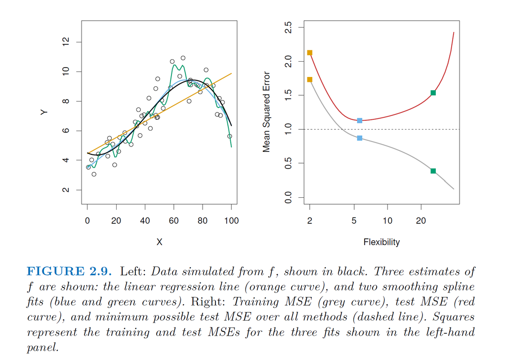

Figure 2.9 from ISL

# Model accuracy for classifications

There are several types of errors in classification models.

## Sensitivity and specificity

Assume a binary classification model, where the true states are $Y\in \{True,False\}$ and the predicted states are $\hat{f} \in \{+,-\}$. The two types of errors can be summarised in a confusion matrix:

|  | FALSE | TRUE |
| --- | --- | --- |
| - | TN | FN |
| + | FP | TP |

- Erroneous predictions FP: frequency of False Positives

FN: frequency of False Negatives

- Correct predictions TN: frequency of True Negatives

TP: frequency of True Positives

Let $n$ be the total number of observations in the data set. Useful performance metrics:

- *Accuracy* is $\frac{TN+TP}{n}$

If we want to distinguish and find a balance between the two types of errors we can use:

- *Sensitivity* is $\frac{TP}{TP + FN}$
- *Specificity* is $\frac{TN}{TN + FP}$

## Receiver Operating Characteristic (ROC) curve

A classification model makes the classification by comparing a scoring variable $S(X)$ to a threshold, $t$. The ROC-methodology can help modellers to choose a threshold taking into account a trade-off between two types of errors, or to compare classifiers without choosing a threshold.

1. For each choice of $t$ derive specificity and sensitivity.
2. The ROC-curve is sensitivity against 1-specificity over different values on the threshold.

Here we exemplify the ROC methodology with the data set [Binary Classification Prediction for type of Breast Cancer](https://www.kaggle.com/datasets/yasserh/breast-cancer-dataset?resource=download) downloaded from Kaggle. The response variable *diagnosis* describes a cancer as Malignant or Benign. We illustrate using the mean radius and the mean compactness as predictors, one per classifier.

- Mean radius as predictor

```
  threshold specificity sensitivity
1      -Inf 0.000000000           1
2    7.3360 0.002801120           1
3    7.7100 0.005602241           1
4    7.7445 0.008403361           1
5    7.9780 0.011204482           1
6    8.2075 0.014005602           1
```

- Mean compactness as predictor

```
  threshold specificity sensitivity
1      -Inf 0.000000000           1
2  0.021410 0.002801120           1
3  0.024970 0.005602241           1
4  0.026625 0.008403361           1
5  0.028955 0.011204482           1
6  0.031640 0.014005602           1
```

- ROC plot with both classifiers

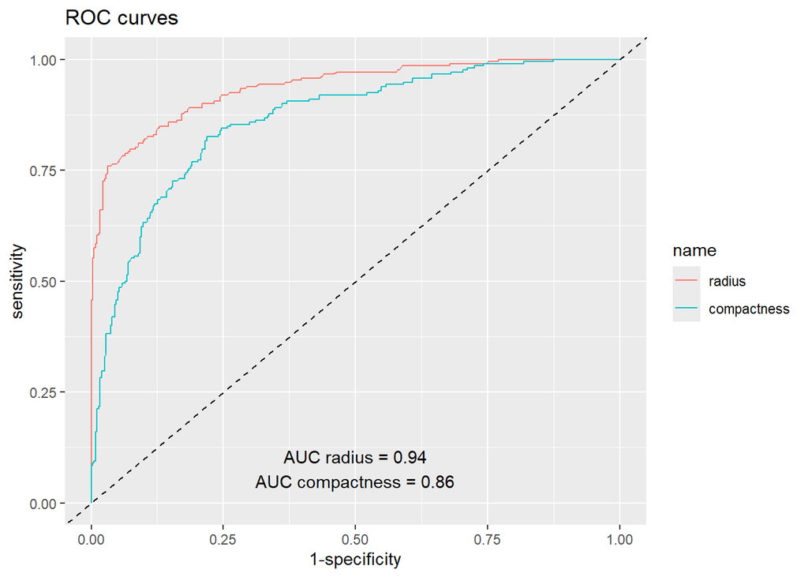

- A model above the 50:50 line is better than tossing a coin.
- The closer to the upper left, the better classification model.
- The measure Area Under the Curve (AUC) offers a way to compare the performance of classifiers without selecting a value on the cutoff.

## Parametric vs non-parametric approaches

Models for statistical learning can be

- parametric, where prediction boils down to estimating parameters within a defined model structure, or
- non-parametric, where the model predicts by an algorithm responding to training data, without any estimation of specific parameters.

> It is useful to discuss the advantages and disadvantages of the two approaches.

## Comparison to unsupervised learning

In principle, unsupervised learning has

- No response variable
- Only a multivariate data set of variables

The goals of unsupervised learning can be to

- Find patterns in data
- Reduce dimensions of data

# Study questions

1. What is the quantity of interest in predictive inference?
2. What are the quantities of interest in parametric inference?
3. Is there a difference between estimation and prediction? If so, what is the difference?
4. What is meant by training data in statistical learning?
5. Break the expression for the predictive variance $V(\hat{Y}|x_0)$ into parts and describe what source of variation that are represented by the different parts?
6. What is the Residual Sum of Squares and what is it used for?
7. What are the differences between regression and classification when it comes to response variable and how predictive errors are expressed quantitatively.
8. Explain the differences between categorical, continuous and discrete variables!
9. What is sensitivity and specificity, and what is it used for?
10. How can a ROC curve analysis be used to compare the performance of two classifiers?
11. What is the main difference between a parametric and non-parametric model for supervised learning?
12. Account for the differences between supervised and unsupervised statistical learning.